# Baby Names

Nathan Moore

2024-03-28

Baby names become very interesting when you have a child.

New Zealand publishes the baby names that were used during the previous year in January. The list has all the years back to 1900. I think I’d like to do a little post about the data. The file only shows names with more than 10 entries. That means that some of the following percentages will be off. I’m guessing that they are good enough for these illustrative purposes.

https://smartstart.services.govt.nz/news/baby-names

https://catalogue.data.govt.nz/dataset/baby-name-popularity-over-time

```r
library(here)
library(dplyr)
library(ggplot2)

names = read.csv(here('static', 'data', 'baby-names-2024-01-08.csv'))

names = names |>
    group_by(Year, Sex) |>
    mutate(rank = rank(-Count, ties.method = 'first'),
           fraction = Count / sum(Count))
```

Questions about the data: have names become more spread out over time? I should check the percentage of the top ten out of the whole, and how many names are in the list at all. Again, this isn’t totally representative because the data is trimmed at a minimum of ten names per year, but it will work.

A ranking chart to show how popularity has changed over time would be interesting: any names that were number one at any time, show them up and down in the top 100.

Are there differences between boys and girls? Popularity, names that occur in both lists, how high do they get?

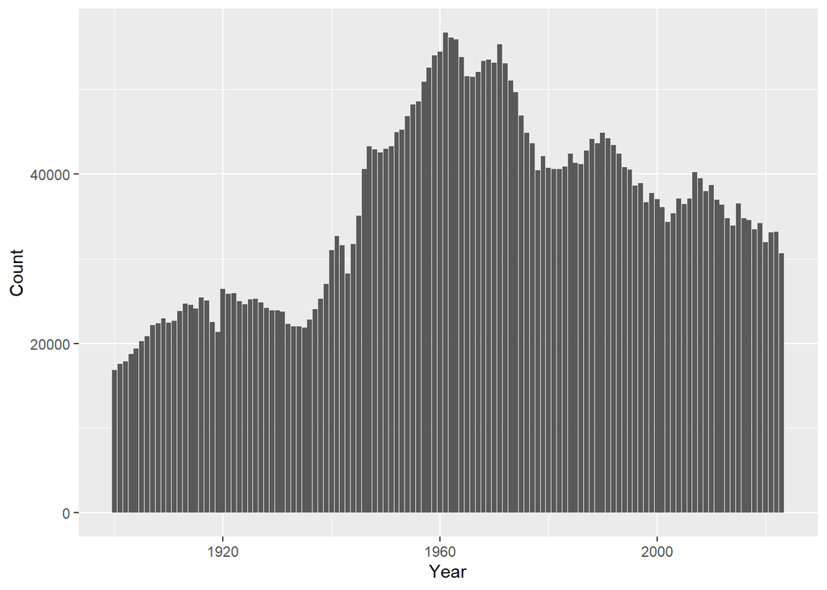

```r
names |>
  ggplot(aes(x = Year, y = Count)) +
  geom_col()
```